# 5.1 Introduction to pandas Data Structures

- To get started with pandas, you will need to get comfortable with its two workhorse data structures: `Series` and `DataFrame`.
- While they are not a universal solution for every problem, they provide a solid, easy-to-use basis for most applications.

### 1. Series

A Series is a **one-dimensional array-like object** containing a sequence of values (of similar types to NumPy types) and an **associated array of data labels, called its `index`**.  
The simplest Series is formed from only an array of data:

```python
import pandas as pd
import numpy as np
```

```python
obj = pd.Series([4,7,-5,3])
obj
```

```
0    4
1    7
2   -5
3    3
dtype: int64
```

You can get the array representation and index object of the Series via its `values` and `index` attributes, respectively:

```python
obj.values
```

```
array([ 4,  7, -5,  3], dtype=int64)
```

```python
obj.index # like range(4)
```

```
RangeIndex(start=0, stop=4, step=1)
```

Often it will be desirable to create a Series with an `index` identifying each data point with a label:

```python
obj2 = pd.Series([4, 7, -5, 3], index=['d', 'b', 'a', 'c'])
obj2
```

```
d    4
b    7
a   -5
c    3
dtype: int64
```

```python
obj2.index
```

```
Index(['d', 'b', 'a', 'c'], dtype='object')
```

Compared with NumPy arrays, **you can use labels in the index when selecting single values or a set of values:**

```python
print(obj2['a'])
obj2['d'] = 6
print(obj2[['c','a','d']])
```

```
-5
c    3
a   -5
d    6
dtype: int64
```

Using NumPy functions or NumPy-like operations, such as **filtering with a boolean array, scalar multiplication, or applying math functions,** will preserve the index-value link:

```python
obj2[obj2 > 0]
```

```
d    6
b    7
c    3
dtype: int64
```

```python
obj2 * 2
```

```
d    12
b    14
a   -10
c     6
dtype: int64
```

```python
np.exp(obj2)
```

```
d     403.428793
b    1096.633158
a       0.006738
c      20.085537
dtype: float64
```

- Another way to think about a **Series is as a fixed-length, ordered dict**, as it is a mapping of index values to data values.
- It can be used in many contexts where you might use a dict:

```python
print('b' in obj2)
print('e' in obj2)
```

```
True
False
```

Should you have data contained in a Python dict, you can create a Series from it by passing the dict:

```python
sdata = {'Ohio': 35000, 'Texas': 71000, 'Oregon': 16000, 'Utah': 5000}
obj3 = pd.Series(sdata)
obj3
```

```
Ohio      35000
Texas     71000
Oregon    16000
Utah       5000
dtype: int64
```

Here, three values found in sdata were placed in the appropriate locations, but sinceno value for 'California' was found, it appears **as `NaN` (not a number), which is considered in pandas to mark missing or `NA` values.** Since 'Utah' was not included in states, it is excluded from the resulting object.

```python
states = ['California', 'Ohio', 'Oregon', 'Texas']
obj4 = pd.Series(sdata, index=states)
obj4
```

```
California        NaN
Ohio          35000.0
Oregon        16000.0
Texas         71000.0
dtype: float64
```

The `isnull` and `notnull` functions in pandas should be used to detect missing data

```python
print(pd.isnull(obj4))
print(pd.notnull(obj4))
```

```
California     True
Ohio          False
Oregon        False
Texas         False
dtype: bool
California    False
Ohio           True
Oregon         True
Texas          True
dtype: bool
```

Series also has these as instance methods:

```python
obj4.isnull()
```

```
California     True
Ohio          False
Oregon        False
Texas         False
dtype: bool
```

A useful Series feature for many applications is that it automatically aligns by index label in arithmetic operations:

```python
print(obj3)
print(obj4)
```

```
Ohio      35000
Texas     71000
Oregon    16000
Utah       5000
dtype: int64
California        NaN
Ohio          35000.0
Oregon        16000.0
Texas         71000.0
dtype: float64
```

```python
obj3 + obj4
```

```
California         NaN
Ohio           70000.0
Oregon         32000.0
Texas         142000.0
Utah               NaN
dtype: float64
```

**Both the Series object itself and its index have a `name` attribute,** which integrates with other key areas of pandas functionality:

```python
obj4.name = 'income'
obj4.index.name = 'state'
obj4
```

```
state
California        NaN
Ohio          35000.0
Oregon        16000.0
Texas         71000.0
Name: income, dtype: float64
```

#### A Series’s index can be altered in-place by assignment:

```python
obj
```

```
0    4
1    7
2   -5
3    3
dtype: int64
```

```python
obj.index = ['Bob', 'Steve', 'Jeff', 'Ryan']
obj
```

```
Bob      4
Steve    7
Jeff    -5
Ryan     3
dtype: int64
```

### 2. DataFrame

- A DataFrame represents a rectangular table of data and contains an ordered collection of columns, each of which can be a different value type (numeric, string, boolean, etc.).
- The DataFrame has both a row and column index; it can be thought of as a dict of Series all sharing the same index.
- Under the hood, **the data is stored as one or more two-dimensional blocks** rather than a list, dict, or some other collection of one-dimensional arrays.

```python
data = {'state': ['Ohio', 'Ohio', 'Ohio', 'Nevada', 'Nevada', 'Nevada'],
'year': [2000, 2001, 2002, 2001, 2002, 2003],
'pop': [1.5, 1.7, 3.6, 2.4, 2.9, 3.2]}
frame = pd.DataFrame(data)
frame
```

|  | state | year | pop |
| --- | --- | --- | --- |
| 0 | Ohio | 2000 | 1.5 |
| 1 | Ohio | 2001 | 1.7 |
| 2 | Ohio | 2002 | 3.6 |
| 3 | Nevada | 2001 | 2.4 |
| 4 | Nevada | 2002 | 2.9 |
| 5 | Nevada | 2003 | 3.2 |

#### For large DataFrames, the head method selects only the first five rows:

```python
frame.head()
```

|  | state | year | pop |
| --- | --- | --- | --- |
| 0 | Ohio | 2000 | 1.5 |
| 1 | Ohio | 2001 | 1.7 |
| 2 | Ohio | 2002 | 3.6 |
| 3 | Nevada | 2001 | 2.4 |
| 4 | Nevada | 2002 | 2.9 |

#### If you specify a sequence of columns, the DataFrame’s columns will be arranged in that order:

```python
pd.DataFrame(data, columns=['year', 'state', 'pop'])
```

|  | year | state | pop |
| --- | --- | --- | --- |
| 0 | 2000 | Ohio | 1.5 |
| 1 | 2001 | Ohio | 1.7 |
| 2 | 2002 | Ohio | 3.6 |
| 3 | 2001 | Nevada | 2.4 |
| 4 | 2002 | Nevada | 2.9 |
| 5 | 2003 | Nevada | 3.2 |

#### If you pass a column that isn’t contained in the dict, it will appear with missing values in the result:

```python
frame2 = pd.DataFrame(data, columns=['year', 'state', 'pop', 'debt'],\
                      index=['one', 'two', 'three', 'four', 'five', 'six'])
frame2
```

|  | year | state | pop | debt |
| --- | --- | --- | --- | --- |
| one | 2000 | Ohio | 1.5 | NaN |
| two | 2001 | Ohio | 1.7 | NaN |
| three | 2002 | Ohio | 3.6 | NaN |
| four | 2001 | Nevada | 2.4 | NaN |
| five | 2002 | Nevada | 2.9 | NaN |
| six | 2003 | Nevada | 3.2 | NaN |

```python
frame2.columns
```

```
Index(['year', 'state', 'pop', 'debt'], dtype='object')
```

**A column in a DataFrame can be retrieved as a Series** either by dict-like notation or by attribute:

```python
frame2['state']
```

```
one        Ohio
two        Ohio
three      Ohio
four     Nevada
five     Nevada
six      Nevada
Name: state, dtype: object
```

```python
frame2.year
```

```
one      2000
two      2001
three    2002
four     2001
five     2002
six      2003
Name: year, dtype: int64
```

**frame2[column] works for any column name, but frame2.column only works when the column name is a valid Python variable name.**

**Rows can also be retrieved by position or name with the special `loc` attribute**

```python
frame2.loc['three']
```

```
year     2002
state    Ohio
pop       3.6
debt      NaN
Name: three, dtype: object
```

Columns can be modified by assignment. For example, the empty 'debt' column could be assigned a scalar value or an array of values:

```python
frame2
```

|  | year | state | pop | debt |
| --- | --- | --- | --- | --- |
| one | 2000 | Ohio | 1.5 | NaN |
| two | 2001 | Ohio | 1.7 | NaN |
| three | 2002 | Ohio | 3.6 | NaN |
| four | 2001 | Nevada | 2.4 | NaN |
| five | 2002 | Nevada | 2.9 | NaN |
| six | 2003 | Nevada | 3.2 | NaN |

```python
frame2['debt'] = 16.5
frame2
```

|  | year | state | pop | debt |
| --- | --- | --- | --- | --- |
| one | 2000 | Ohio | 1.5 | 16.5 |
| two | 2001 | Ohio | 1.7 | 16.5 |
| three | 2002 | Ohio | 3.6 | 16.5 |
| four | 2001 | Nevada | 2.4 | 16.5 |
| five | 2002 | Nevada | 2.9 | 16.5 |
| six | 2003 | Nevada | 3.2 | 16.5 |

```python
frame2['debt'] = np.arange(6.)
frame2
```

|  | year | state | pop | debt |
| --- | --- | --- | --- | --- |
| one | 2000 | Ohio | 1.5 | 0.0 |
| two | 2001 | Ohio | 1.7 | 1.0 |
| three | 2002 | Ohio | 3.6 | 2.0 |
| four | 2001 | Nevada | 2.4 | 3.0 |
| five | 2002 | Nevada | 2.9 | 4.0 |
| six | 2003 | Nevada | 3.2 | 5.0 |

- When you are assigning lists or arrays to a column, the value’s length must match the length of the DataFrame.
- If you assign a Series, its labels will be realigned exactly to the DataFrame’s index, inserting missing values in any holes:

```python
val = pd.Series([-1.2, -1.5, -1.7], index=['two', 'four', 'five'])
frame2['debt'] = val
frame2
```

|  | year | state | pop | debt |
| --- | --- | --- | --- | --- |
| one | 2000 | Ohio | 1.5 | NaN |
| two | 2001 | Ohio | 1.7 | -1.2 |
| three | 2002 | Ohio | 3.6 | NaN |
| four | 2001 | Nevada | 2.4 | -1.5 |
| five | 2002 | Nevada | 2.9 | -1.7 |
| six | 2003 | Nevada | 3.2 | NaN |

#### Assigning a column that doesn’t exist will create a new column. The `del` keyword will delete columns as with a dict.

```python
frame2['eastern'] = frame2.state == 'Ohio'
frame2
```

|  | year | state | pop | debt | eastern |
| --- | --- | --- | --- | --- | --- |
| one | 2000 | Ohio | 1.5 | NaN | True |
| two | 2001 | Ohio | 1.7 | -1.2 | True |
| three | 2002 | Ohio | 3.6 | NaN | True |
| four | 2001 | Nevada | 2.4 | -1.5 | False |
| five | 2002 | Nevada | 2.9 | -1.7 | False |
| six | 2003 | Nevada | 3.2 | NaN | False |

```python
del frame2['eastern']
frame2.columns
```

```
Index(['year', 'state', 'pop', 'debt'], dtype='object')
```

#### Another common form of data is a nested dict of dicts:

```python
pop = {'Nevada': {2001: 2.4, 2002: 2.9},\
       'Ohio': {2000: 1.5, 2001: 1.7, 2002: 3.6}}
frame3 = pd.DataFrame(pop, index=[2000, 2001, 2002])
frame3
```

|  | Nevada | Ohio |
| --- | --- | --- |
| 2000 | NaN | 1.5 |
| 2001 | 2.4 | 1.7 |
| 2002 | 2.9 | 3.6 |

You can transpose the DataFrame (swap rows and columns) with similar syntax to a NumPy array

```python
frame3.T
```

|  | 2000 | 2001 | 2002 |
| --- | --- | --- | --- |
| Nevada | NaN | 2.4 | 2.9 |
| Ohio | 1.5 | 1.7 | 3.6 |

If a DataFrame’s index and columns have their name attributes set, these will also be displayed:

```python
frame3.index.name = 'year'; frame3.columns.name = 'state'
frame3
```

| state year | Nevada | Ohio |
| --- | --- | --- |
| 2000 | NaN | 1.5 |
| 2001 | 2.4 | 1.7 |
| 2002 | 2.9 | 3.6 |

As with Series, the `values` attribute returns **the data contained in the DataFrame as a two-dimensional ndarray**:

```python
frame3.values
```

```
array([[nan, 1.5],
       [2.4, 1.7],
       [2.9, 3.6]])
```

#### If the DataFrame’s columns are different dtypes, the `dtype` of the values array will be chosen to accommodate all of the columns:

```python
frame2
```

|  | year | state | pop | debt |
| --- | --- | --- | --- | --- |
| one | 2000 | Ohio | 1.5 | NaN |
| two | 2001 | Ohio | 1.7 | -1.2 |
| three | 2002 | Ohio | 3.6 | NaN |
| four | 2001 | Nevada | 2.4 | -1.5 |
| five | 2002 | Nevada | 2.9 | -1.7 |
| six | 2003 | Nevada | 3.2 | NaN |

```python
frame2.values
```

```
array([[2000, 'Ohio', 1.5, nan],
       [2001, 'Ohio', 1.7, -1.2],
       [2002, 'Ohio', 3.6, nan],
       [2001, 'Nevada', 2.4, -1.5],
       [2002, 'Nevada', 2.9, -1.7],
       [2003, 'Nevada', 3.2, nan]], dtype=object)
```

#### For a complete list of things you can pass the DataFrame constructor, see Table 5-1

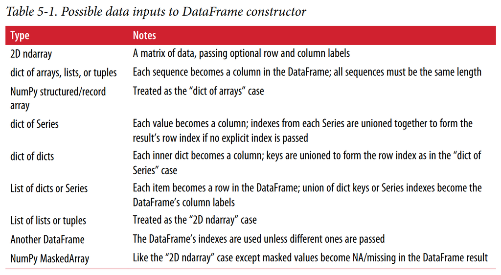

### 3. Index Objects

- pandas’s Index objects are responsible for holding the axis labels and other metadata (like the axis name or names).
- Any array or other sequence of labels you use when constructing a Series or DataFrame is internally converted to an Index:

```python
obj = pd.Series(range(3), index=['a', 'b', 'c'])
index = obj.index
index
```

```
Index(['a', 'b', 'c'], dtype='object')
```

```python
index[1:]
```

```
Index(['b', 'c'], dtype='object')
```

#### Index objects are immutable and thus can’t be modified by the user:

Immutability makes it safer to share Index objects among data structures:

```python
index[1] = 'd' # TypeError
```

```
---------------------------------------------------------------------------
TypeError                                 Traceback (most recent call last)
<ipython-input-43-1a15f4fda8a8> in <module>
----> 1 index[1] = 'd' # TypeError

E:\Anaconda\lib\site-packages\pandas\core\indexes\base.py in __setitem__(self, key, value)
   3908
   3909     def __setitem__(self, key, value):
-> 3910         raise TypeError("Index does not support mutable operations")
   3911
   3912     def __getitem__(self, key):

TypeError: Index does not support mutable operations
```

```python
labels = pd.Index(np.arange(3))
labels
```

```
Int64Index([0, 1, 2], dtype='int64')
```

```python
obj2 = pd.Series([1.5, -2.5, 0], index=labels)
obj2
```

```
0    1.5
1   -2.5
2    0.0
dtype: float64
```

```python
obj2.index is labels
```

```
True
```

#### Unlike Python sets, a pandas Index can contain duplicate labels:

```python
frame3
```

| state year | Nevada | Ohio |
| --- | --- | --- |
| 2000 | NaN | 1.5 |
| 2001 | 2.4 | 1.7 |
| 2002 | 2.9 | 3.6 |

```python
frame3.columns
```

```
Index(['Nevada', 'Ohio'], dtype='object', name='state')
```

```python
frame3.index
```

```
Int64Index([2000, 2001, 2002], dtype='int64', name='year')
```

```python
'Ohio' in frame3.columns
```

```
True
```

```python
2003 in frame3.index
```

```
False
```

```python
dup_labels = pd.Index(['foo', 'foo', 'bar', 'bar'])
dup_labels
```

```
Index(['foo', 'foo', 'bar', 'bar'], dtype='object')
```

#### Notice, Selections with duplicate labels will select all occurrences of that label.

Each Index has a number of methods and properties for set logic, which answer other common questions about the data it contains. Some useful ones are summarized in Table 5-2

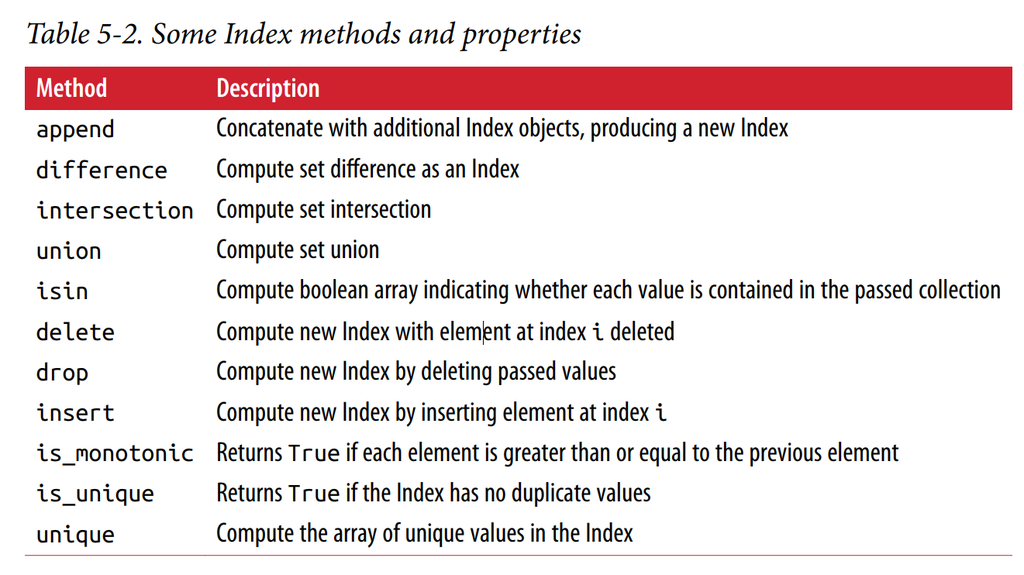